# Classifying Kangaroo Species Using Skull Morphology Through the Lens of Statistical Machine Learning

STAT 253

Author

Rosie, William, Georgia and Lucia

Published

November 14, 2025

# Research Goals

The goal of this report is to build a predictive classification model that can determine a kangaroo’s species from skull measurements. Correctly identifying species from skeletal features is useful in ecological monitoring, museum curation, and paleontology field research where complete specimens are rare. In addition to developing and evaluating our predictive algorithm, we aim to highlight which skull characteristics most strongly distinguish species, supported by visualizations and model-based evidence.

# Data

Our training dataset is made up of skull measurements from 148 individual kangaroos collected for research. The who represents three species of kangaroos: fuliginosus (n=50), giganteus (n=50), and melanops (n=48). The what consists of 20 cranial measurements captured in millimeters, including features such as basilar length, nasal dimensions, palate measurements, zygomatic width, and mandible characteristics, along with the sex of each specimen. The why centers on species identification being able to accurately classify kangaroo species from skeletal remains is crucial for paleontological research and ecological monitoring where complete specimens may be unavailable. The how involves precise cranial measurements taken from skulls using standardized morphometric techniques.

The focus outcome variable in this study is ‘species’ which has three groups: fuliginosus, giganteus, and melanops. It is important to metion that fuliginosus and melanops are actually the same biological species since both represent the Western Grey Kangaroo (Macropus fuliginosus) with “melanops” historically used to describe specimens from a specific geographic region before being taxonomically synonymized with fuliginosus.[Source](https://animaldiversity.org/accounts/Macropus_fuliginosus/). This informed our modeling strategy.

Species Distribution

| species | n |
| --- | --- |
| fuliginosus | 50 |
| giganteus | 50 |
| melanops | 48 |

Missing Values Summary

| Variable | Missing |
| --- | --- |
| palate.width | 24 |
| mandible.length | 12 |
| occipital.depth | 11 |
| .rostral.width | 3 |
| occipitonasal.length | 2 |
| basilar.length | 1 |
| palate.length | 1 |
| nasal.length | 1 |
| squamosal.depth | 1 |
| zygomatic.width | 1 |

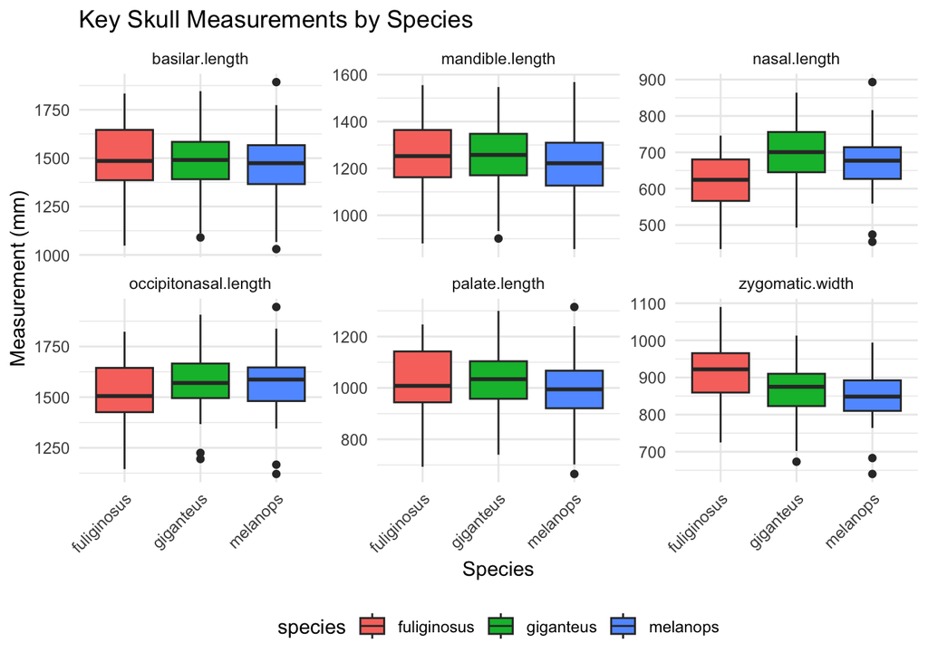

# Model Building

# Implementation

We used tidymodels to implement this model building process. See code below for full details.

**View Code**

```r
# group fuliginosus and melanops together (same species biologically)
kangaroo_data_lasso <- kangaroo %>%
  mutate(group_species = case_when(
    species == "giganteus" ~ "Giganteus",
    species %in% c("fuliginosus", "melanops") ~ "Fuliginosus"))

# encode species groups as numeric for lasso
lasso_kangaroo <- kangaroo_data_lasso %>%
  mutate(group_species = case_when(
    group_species == "Giganteus" ~ 0,
    group_species == "Fuliginosus" ~ 1)) %>%
  select(-species)  # remove the original species variable

# set up lasso model specification
lasso_spec <- linear_reg() %>%
  set_mode("regression") %>%
  set_engine("glmnet") %>%
  set_args(mixture = 1, penalty = tune())

# create recipe with preprocessing steps
kangaroo_recipe <- recipe(group_species ~ ., data = lasso_kangaroo) %>%
  step_nzv(all_predictors()) %>%
  step_impute_knn(all_predictors()) %>%
  step_dummy(all_nominal_predictors())

lasso_workflow <- workflow() %>%
  add_recipe(kangaroo_recipe) %>%
  add_model(lasso_spec)

set.seed(253)
lasso_models <- lasso_workflow %>%
  tune_grid(
    grid = grid_regular(penalty(range = c(-5, 1)), levels = 100),
    resamples = vfold_cv(lasso_kangaroo, v = 10),
    metrics = metric_set(mae)
  )

# use penalty to see variable selection
parsiminious_penalty <- lasso_models %>%
  select_by_one_std_err(metric = "mae", desc(penalty))

final_lasso_model <- lasso_workflow %>%
  finalize_workflow(parameters = parsiminious_penalty) %>%
  fit(data = lasso_kangaroo)

# view selected variables with non-zero coefficients
final_lasso_model %>%
  tidy() %>%
  filter(estimate!=0)
```

```
# A tibble: 14 × 3
   term                  estimate penalty
   <chr>                    <dbl>   <dbl>
 1 (Intercept)           0.334    0.00933
 2 basilar.length        0.000531 0.00933
 3 occipitonasal.length  0.000265 0.00933
 4 palate.width         -0.00241  0.00933
 5 nasal.length         -0.00301  0.00933
 6 nasal.width          -0.00586  0.00933
 7 lacrymal.width        0.00258  0.00933
 8 orbital.width         0.00205  0.00933
 9 .rostral.width        0.00210  0.00933
10 occipital.depth      -0.00272  0.00933
11 foramina.length      -0.000111 0.00933
12 mandible.width        0.000725 0.00933
13 mandible.depth       -0.00136  0.00933
14 ramus.height          0.00407  0.00933
```

```r
# create dataset with lasso-selected variables only
lasso_select <- kangaroo_data_lasso %>%
  select(group_species, basilar.length, occipitonasal.length,
         palate.width, nasal.length, nasal.width, lacrymal.width,
         orbital.width, .rostral.width, occipital.depth, foramina.length,
         mandible.width, mandible.depth, ramus.height)

# set up logistic regression specification
logistic_spec <- logistic_reg() %>%
  set_mode("classification") %>%
  set_engine("glm")

# create recipe with knn imputation for selected variables
kangaroo_recipe <- recipe(group_species ~ ., data = lasso_select) %>%
  step_impute_knn(all_predictors())

# combine recipe and logistic model into workflow
logistic_workflow <- workflow() %>%
  add_recipe(kangaroo_recipe) %>%
  add_model(logistic_spec)

# fit logistic regression model on full dataset
log_kangaroo <- logistic_workflow %>%
  fit(data = lasso_select)

# evaluate model using 10-fold cross-validation
set.seed(253)
log_kangaroo_cv <- logistic_workflow %>%
  fit_resamples(
    resamples = vfold_cv(lasso_select, v = 10),
    control = control_resamples(save_pred = TRUE, event_level = 'second'),
    metrics = metric_set(accuracy, sens, spec, roc_auc)  # AUC averaged from 10 folds

  )

# display cross-validated performance metrics
log_kangaroo_cv %>%
  collect_metrics()
```

```
# A tibble: 4 × 6
  .metric  .estimator  mean     n std_err .config
  <chr>    <chr>      <dbl> <int>   <dbl> <chr>
1 accuracy binary     0.831    10  0.0255 pre0_mod0_post0
2 roc_auc  binary     0.934    10  0.0212 pre0_mod0_post0
3 sens     binary     0.720    10  0.0728 pre0_mod0_post0
4 spec     binary     0.910    10  0.0278 pre0_mod0_post0
```

# Model Evaluation

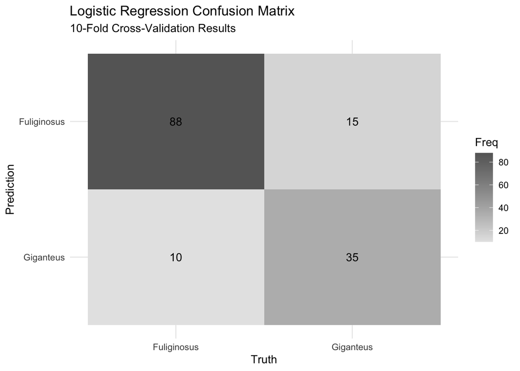

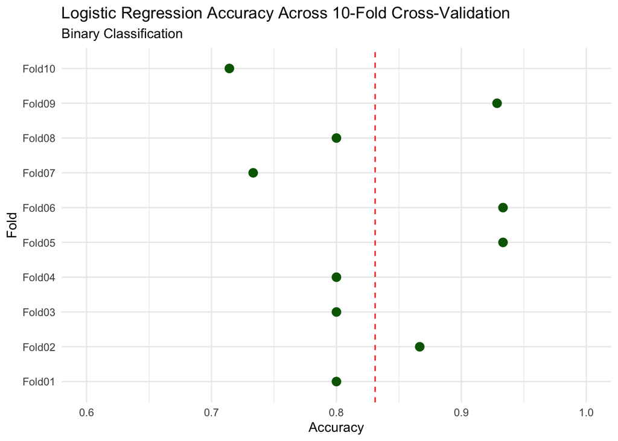

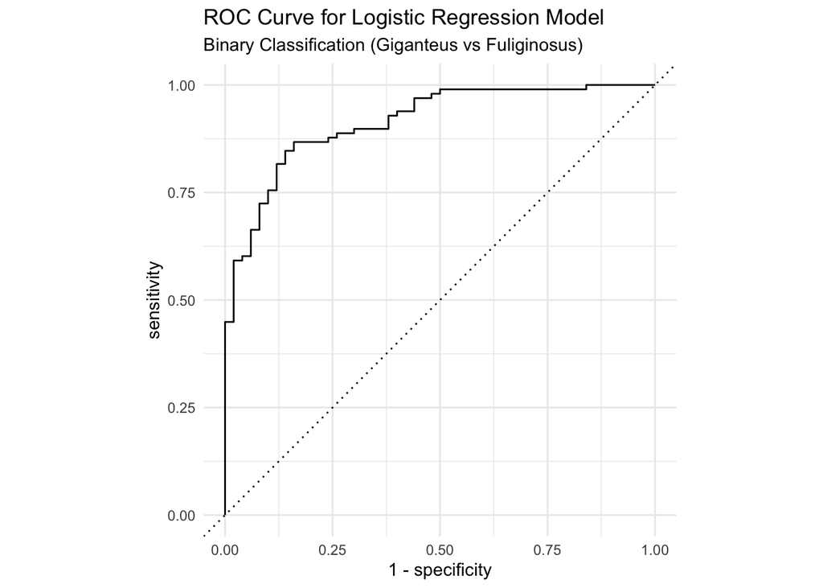

Area Under the ROC Curve (AUC)

| .metric | .estimator | .estimate |
| --- | --- | --- |
| roc_auc | binary | 0.914 |

Our model’s accuracy is 83%, meaning that our model’s ability of correctly distinguishing between Fuliginosis and Giganteus species is correct 83 percent of the times. Looking at other metrics, the sensitivity of this model is 0.72, meaning that it correctly predicts our reference category Ginganteus as Ginganteus about 72% of the time. In contrast, the specificity is approximately 0.91, indicating that the model correctly predicts Fuliginosus as Fuliginosus about 91% of the time. This difference among sensitivity and specificity makes sense in the context of the data as there are more abundant values for the Fuliginosus species. These results can be calculated manually from the logistic regression confusion matrix to further enhance our results.These three metrics suport that this model’s ability to make predictions is strong, specifically for predicting Fuliginosus.

Another metric to evaluate this model is the Area Under the Curve (AUC), which has a value of 0.914. This indicates that the model can distinguish well between Fuliginosus and Giganteus about 91–92% of the time. While these performance metrics are strong, they might raise concerns about potential overfitting. However, the use of cross-validation and LASSO during model training helps mitigate this risk by testing the model on unseen folds of the data and reducing the number of predictors while preserving accuracy.

# Contributions

Model exploration was evenly distributed across all four team members. Rosie investigated decision trees and random forests, Lucia explored KNN, and Georgia and William worked together on logistic regression with LASSO variable selection. After running all models, we compared results and collaboratively selected the best model based on accuracy and mapping the two subspecies of the kangaroos together. Additionally, individual contributions included Georgia researching kangaroo taxonomy to support the binary classification, William examining approaches for handling missing data—specifically the use of step_impute_knn, Lucia interpreting and explaining model evaluation metrics, and Rosie troubleshooting issues within the tree and forest algorithms. Finally, we wrote this report collaboratively, reviewing and providing feedback on each section as a group.

# Random Tree and Forest Exploration (Rosie)

**View Code**

```r
tree_spec <- decision_tree() %>%
  set_mode("classification") %>%
  set_engine("rpart") %>%
  set_args(cost_complexity = tune(), min_n = 2, tree_depth = 30)

tree_recipe <- recipe(species ~ ., data = kangaroo)

tree_wf <- workflow() %>%
  add_recipe(tree_recipe) %>%
  add_model(tree_spec)


set.seed(253)
tree_models <- tree_wf %>%
  tune_grid(
    grid = grid_regular(cost_complexity(range = c(-5, 0.1)), levels = 20),
    resamples = rs,
    metrics = metric_set(accuracy))

best_cost <- select_best(tree_models, metric = "accuracy")
final_tree <- tree_wf %>% finalize_workflow(best_cost) %>% fit(kangaroo)

final_tree %>% extract_fit_engine() %>% rpart.plot()
```

```r
tree_models %>%
  collect_metrics() %>%
  dplyr::filter(.metric == "accuracy") %>%
  dplyr::arrange(desc(mean)) %>%
  dplyr::slice(1)
```

```r
rf_spec <- rand_forest() %>%
  set_mode("classification") %>%
  set_engine("ranger") %>%
  set_args(
    mtry = NULL,
    trees = 500,
    min_n = 2,
    probability = FALSE,
    importance = "impurity")

age_forest <- rf_spec %>% fit(species ~ ., data = kangaroo)

imp_vec <- age_forest %>% extract_fit_engine() %>%
  pluck("variable.importance") %>% sort(decreasing = TRUE)
imp_vec

age_forest %>% vip(geom = "point", num_features = 15)
```

# Knn with LASSO exploration (Lucia)

**View Code**

```r
knn_select <- kangaroo %>%
  select(species, basilar.length, occipitonasal.length,
         palate.length, palate.width, nasal.length,
         nasal.width, squamosal.depth)

knn_spec <- nearest_neighbor() %>%
  set_mode("classification") %>%
  set_engine(engine = "kknn") %>%
  set_args(neighbors = tune())

variable_recipe <- recipe(species ~., data = knn_select) %>%
  step_nzv(all_predictors()) %>%
  step_impute_knn(all_predictors()) %>%
  step_dummy(all_nominal_predictors()) %>%
  step_normalize(all_numeric_predictors())

knn_workflow <- workflow() %>%
  add_recipe(variable_recipe) %>%
  add_model(knn_spec)

set.seed(253)
knn_models <- knn_workflow %>%
  tune_grid(
    grid = grid_regular(neighbors(range = c(1, 74)), levels = 50),
    resamples = vfold_cv(knn_select, v = 10),
    metrics = metric_set(accuracy)
  )

knn_models %>%
  autoplot()

best_k <- knn_models %>%
  select_best()
best_k

knn_models %>%
  collect_metrics() %>%
  filter(neighbors == best_k$neighbors)

final_knn_model <- knn_workflow %>%
  finalize_workflow(parameters = best_k) %>%
  fit(data = knn_select)
```

# Decision Tree with LASSO (William)

**View Code**

```r
tree_select <- kangaroo %>%
  select(species, basilar.length, occipitonasal.length,
         palate.length, palate.width, nasal.length,
         nasal.width, squamosal.depth)


tree_spec <- decision_tree() %>%
  set_mode("classification") %>%
  set_engine("rpart") %>%
  set_args(cost_complexity = tune(), min_n = 2, tree_depth = 30)

tree_recipe <- recipe(species ~ ., data = tree_select) %>%
  step_impute_knn(all_predictors())

tree_wf <- workflow() %>%
  add_recipe(tree_recipe) %>%
  add_model(tree_spec)

set.seed(253)
tree_models <- tree_wf %>%
  tune_grid(
    grid = grid_regular(cost_complexity(range = c(-5, 0.1)), levels = 20),
    resamples = vfold_cv(tree_select, v = 10),  # 10-fold CV
    metrics = metric_set(accuracy)
  )

best_cost <- select_best(tree_models, metric = "accuracy")
final_tree <- tree_wf %>%
  finalize_workflow(best_cost) %>%
  fit(tree_select)

final_tree %>% extract_fit_engine() %>% rpart.plot()

tree_models %>%
  collect_metrics() %>%
  dplyr::filter(.metric == "accuracy") %>%
  dplyr::arrange(desc(mean)) %>%
  dplyr::slice(1)
```